# ERA-Explore-and-Analyze

Peter Steward

2022-05-11

## Exploring the data

In this vignette we will cover how to visualize ERA data and run simple meta-analysis.

### Splitting combined practices

Observations in the main `ERA.Compiled` often consist of bundles of practices which may relate to more than one product.

```r
# No. combination practices
nrow(ERA.Compiled[grepl("-",SubPrName)])
```

```
#> [1] 47292
```

```r
# No. solo practices
nrow(ERA.Compiled[!grepl("-",SubPrName)])
```

```
#> [1] 61710
```

This makes visualization of the dataset difficult as there are over a 1000 sub-practice combinations creating too many values to map onto a figure. We can use the `ERAComboSplit` function to “split” these practice and product combinations into duplicate individual rows each contain a unique combination of any practice x product combination present in the original observation.

```r
# There are many subpractice combinations in ERA
ERA.Compiled[grepl("-",SubPrName),length(unique(SubPrName))]
```

```
#> [1] 1156
```

```r
ERA.Compiled[,unique(SubPrName)][1:10]
```

```
#>  [1] "Inputs K-Inputs Micro-Inputs P-Inputs Urea"
#>  [2] "Inputs K-Inputs P-Inputs Urea"
#>  [3] "Inputs P-Inputs Urea"
#>  [4] "Inputs Urea"
#>  [5] "Inputs P"
#>  [6] "Inputs K"
#>  [7] "Inputs K-Inputs P"
#>  [8] "Inputs K-Inputs Urea"
#>  [9] "Inputs N-Inputs Urea"
#> [10] "Residue Unkn (nonNfix; NoFate)"
```

```r
# Lets split these
ERA.Compiled.Split<-ERAComboSplit(Data=ERA.Compiled)

# The dataset gets longer
dim(ERA.Compiled)
```

```
#> [1] 109002    147
```

```r
dim(ERA.Compiled.Split)
```

```
#> [1] 207331    159
```

```r
# Suffixed .Combo columns contain split names and codes
grep(".Combo",colnames(ERA.Compiled.Split),value=T)
```

```
#>  [1] "SubPrName.Combo"            "SubPrName.Code.Combo"
#>  [3] "PrName.Combo"               "PrName.Code.Combo"
#>  [5] "Theme.Combo"                "Theme.Code.Combo"
#>  [7] "Product.Simple.Combo"       "Product.Code.Combo"
#>  [9] "Product.Subtype.Combo"      "Product.Subtype.Combo.Code"
#> [11] "Product.Type.Combo"         "Product.Type.Combo.Code"
```

```r
# Combine codes have gone in the .Combo columns
ERA.Compiled.Split[grepl("-",SubPrName.Combo),length(unique(SubPrName.Combo))]
```

```
#> [1] 0
```

```r
# Only single values are presnt
ERA.Compiled.Split[,unique(SubPrName.Combo)][1:10]
```

```
#>  [1] "Inputs K"                       "Inputs Micro"
#>  [3] "Inputs P"                       "Inputs Urea"
#>  [5] "Inputs N"                       "Residue Unkn (nonNfix; NoFate)"
#>  [7] "Feed Concentrates"              "Feed Crop (Sub)"
#>  [9] "Irrigation Deficit"             "Feed Mech Process"
```

### Treemaps

We can use the “split” dataset to explore how many instance of products, practices or outcomes there are. Treemaps are great way of visualizing these data using the `treemap::treemap()` function.

```r
# First we count the number of studies per level of the practice heirarchy (see PracticeCodes object for more information on the practice heirarchy)
ERA.Compiled.Split.Pracs<-ERA.Compiled.Split[,list(N.Studies=length(unique(Code))),by=list(SubPrName.Combo,PrName.Combo,Theme.Combo)]

head(ERA.Compiled.Split.Pracs)
```

```
#>                   SubPrName.Combo         PrName.Combo         Theme.Combo
#> 1:                       Inputs K Inorganic Fertilizer Nutrient Management
#> 2:                   Inputs Micro Inorganic Fertilizer Nutrient Management
#> 3:                       Inputs P Inorganic Fertilizer Nutrient Management
#> 4:                    Inputs Urea Inorganic Fertilizer Nutrient Management
#> 5:                       Inputs N Inorganic Fertilizer Nutrient Management
#> 6: Residue Unkn (nonNfix; NoFate)         Crop Residue     Soil Management
#>    N.Studies
#> 1:       292
#> 2:        74
#> 3:       504
#> 4:       278
#> 5:       419
#> 6:        21
```

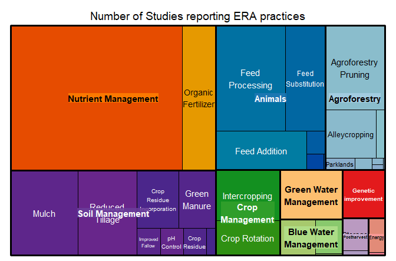

```r
# Visualize with the treemap function
treemap::treemap(ERA.Compiled.Split.Pracs,
      index=c("Theme.Combo","PrName.Combo"),
      vSize="N.Studies",
      type="index",
      palette = "Paired",
      title="Number of Studies reporting ERA practices")
```

## Analyzing Data

In this example we will analyze outcomes for the effectiveness of water harvesting practices using pits.

First let’s explore the ERA `PracticeCodes` to see where we might find the names of the practices we are interested in. Theme is the highest level of organization for practice which of these relate to water harvesting?

```r
PracticeCodes<-data.table(PracticeCodes)

PracticeCodes[,unique(Theme)]
```

```
#>  [1] "Agroforestry"           "Soil Management"        "Blue Water Management"
#>  [4] "Green Water Management" "Crop Management"        "Genetic improvement"
#>  [7] "Nutrient Management"    "Energy"                 "Animals"
#> [10] "Postharvest"            "Non-CSA"                "Water Management"
```

```r
PracticeCodes[Theme=="Water Management",unique(Practice)]
```

```
#> [1] "Irrigation" "Planting"
```

```r
# Note that we are using the Subpractice.S field, this is the field used to generate the names in the ERA.Compiled$SubPrName and ERA.Compiled$SubPrName.Base fields
PracticeCodes[Practice=="Water Harvesting",unique(Subpractice.S)]
```

```
#>  [1] "Water Tanks"        "Zai Pits"           "Stone Rows"
#>  [4] "Grass Strips"       "Planting Basins"    "Dam"
#>  [7] "Terraces"           "Bunds"              "Ridge & Furrow"
#> [10] "Tied Ridges"        "Microcatchments"    "Fanya Juu or Chini"
#> [13] "Trench"
```

Two of these practices seem to relate to pits `Planting Basins` and `Zai Pits`, let’s check their definitions to make sure.

```r
FocalPractices<-c("Planting Basins","Zai Pits")
PracticeCodes[Subpractice %in% FocalPractices,Definition]
```

```
#> [1] "Small pits to capture water. Pits are filled with manure, compost or other nutrient sources before the rainy season. Crops are planted directly into the pits."
#> [2] "Small planting pits dug to capture water, crops are planted directly into the pits."
```

Great both are are types of planting pit.

### Data Availability

Now let’s see what data we have in ERA on these practices

```r
  (PitPracs<-ERA.Compiled[grepl(paste(FocalPractices,collapse = "|"),SubPrName),SubPrName] %>%
  table %>%
  sort(decreasing = T))
```

```
#> .
#>                                                                        MinTill-Planting Basins
#>                                                                                            366
#>                                                                                Planting Basins
#>                                                                                            365
#>                                                        MinTill-Mulch (nonNfix)-Planting Basins
#>                                                                                            123
#>                                               AgFor Prune Mulch (Nfix)-MinTill-Planting Basins
#>                                                                                            100
#>                                                                Mulch (nonNfix)-Planting Basins
#>                                                                                             92
#>                                                                                       Zai Pits
#>                                                                                             58
#>                                            AgFor Prune Mulch (nonNfix)-MinTill-Planting Basins
#>                                                                                             50
#>                                                               Planting Basins-Rotation (Mixed)
#>                                                                                             34
#>                                           MinTill-Mulch (Nfix)-Mulch (nonNfix)-Planting Basins
#>                                                                                             28
#>                                                                   Mulch (noID)-Planting Basins
#>                                                                                             24
#>                                                  Mulch (noID)-Planting Basins-Rotation (Mixed)
#>                                                                                             24
#>                                                                         Inputs Manure-Zai Pits
#>                                                                                             21
#>                                                                         NoTill-Planting Basins
#>                                                                                             21
#>                                                     Inputs K-Inputs N-Inputs P-Planting Basins
#>                                                                                             20
#>                                       AgFor Alley (Nfix)-AgFor Prune (Unknown)-Planting Basins
#>                                                                                             16
#>                  Inputs K-Inputs Manure-Inputs N-Inputs P-MinTill-Mulch (noID)-Planting Basins
#>                                                                                             12
#>                                             Inputs Manure-MinTill-Mulch (noID)-Planting Basins
#>                                                                                             12
#>                                                        Irrigation Supp-MinTill-Planting Basins
#>                                                                                             10
#>                                                                Irrigation Supp-Planting Basins
#>                                                                                             10
#>                                                           Intercrop (Mixed)-pH-Planting Basins
```

[output cut: 24 more lines]

```
#>                                                                                              2
#>                                                      Inputs N-Inputs P-MinTill-Planting Basins
#>                                                                                              2
#>                                                              Inputs N-Inputs P-Planting Basins
#>                                                                                              2
#>                                       MinTill-Mulch (nonNfix)-Planting Basins-Rotation (Mixed)
#>                                                                                              2
#>                                                                               MinTill-Zai Pits
#>                                                                                              2
#>                                 Inputs K-Inputs N-Inputs P-Inputs Urea-MinTill-Planting Basins
#>                                                                                              1
#>                                            Inputs Manure-Inputs P-Inputs Urea-MinTill-Zai Pits
#>                                                                                              1
#>                         Intercrop (Mixed)-MinTill-Mulch (Nfix)-Mulch (nonNfix)-Planting Basins
#>                                                                                              1
```

Try using the `treemap` approach as a way of visualizing the data above.

It seems planting basins are often used in combination with minimum tillage and mulch, together this is known as conservation agriculture. Let’s subset the data to where we have a reasonable number of observations, at least 50.

```r
  PitPracs<-PitPracs[PitPracs>=50] %>% names
  ERA.Pits<-ERA.Compiled[SubPrName %in% PitPracs]
```

What outcomes do we have data for?

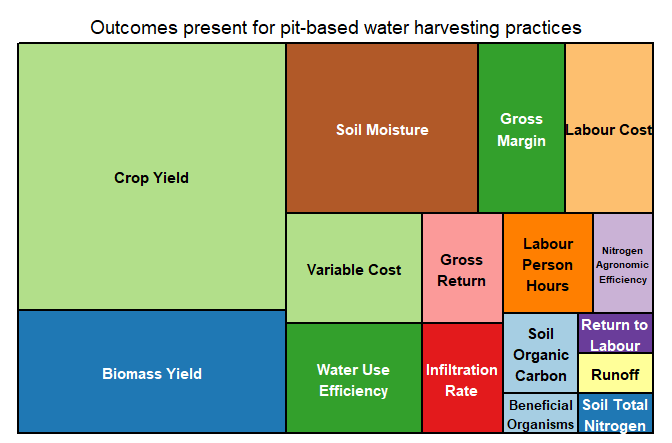

```r
ERA.Pits.Out<-ERA.Pits[,list(N.Studies=length(unique(Code))),by=list(SubPrName,Out.SubInd)]

# Visualize with the treemap function
treemap::treemap(ERA.Pits.Out,
      index=c("Out.SubInd"),
      vSize="N.Studies",
      type="index",
      palette = "Paired",
      title="Outcomes present for pit-based water harvesting practices")
```

What crops do we have data for?

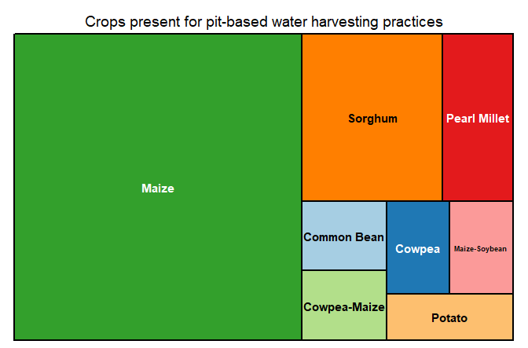

```r
ERA.Pits.Crops<-ERA.Pits[,list(N.Studies=length(unique(Code))),by=list(Product.Simple)]

# Visualize with the treemap function
treemap::treemap(ERA.Pits.Crops,
      index=c("Product.Simple"),
      vSize="N.Studies",
      type="index",
      palette = "Paired",
      title="Crops present for pit-based water harvesting practices")
```

Where does this data come from?

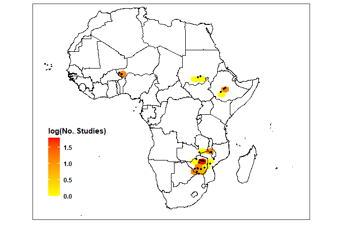

```r
ERAgON::ERAHexPlot(Data=ERA.Pits,Showpoints = "Yes",Point.Col = "black",Mid = "yellow",
  High = "red",)
```

```r
100*(ERA.Pits[,table(Country)] / nrow(ERA.Pits)) %>% round(digits=3)
```

```
#> Country
#>   Ethiopia Mozambique      Niger      Sudan     Zambia   Zimbabwe
#>        3.7        0.4        3.7        4.3        0.8       87.0
```

Where can I find the papers that contain this data?

`ERA.Compiled` provides you with some basic bibliographic data, the most important of which is the `DOI` file which enables you to locate the article on-line when adding the prefix `https://doi.org/` (e.g., `https://doi.org/10.1007/s10705-005-6209-9`).

```r
ERA.Pits[,list(Code,Journal,Author,DOI)] %>%  unique
```

```
#>       Code              Journal         Author                            DOI
#>  1: NN0035 NUTR CYCL AGROECOSYS     Fatondji D      10.1007/s10705-005-6209-9
#>  2: NN0304              EXP AGR Mashingaidze N      10.1017/s0014479712001020
#>  3: HK0259        J SUSTAIN AGR        Umar BB   10.1080/10440046.2012.661700
#>  4: HK0280      PHYS CHEM EARTH     Mupangwa W      10.1016/j.pce.2007.07.030
#>  5: HK0281      PHYS CHEM EARTH     Mupangwa W      10.1016/j.pce,2008.06.049
#>  6: HK0282       FIELD CROP RES     Mupangwa W      10.1016/j.fcr.2012.02.020
#>  7: HK0283       J ARID ENVIRON     Mupangwa W 10.1016/j.jaridenv.2012.11.007
#>  8: HK0347            CROP PROT    Mutsamba EF   10.1016/j.cropro.2016.01.004
#>  9: AN0068  RENEW AGR FOOD SYST    Thierfelder      10.1017/S1742170515000332
#> 10: AN0083        SOIL TILL RES           Sime    10.1016/j.still.2014.12.001
#> 11: AN0093      LAND DEGRAD DEV   Wildemeersch               10.1002/ldr.2416
#> 12: AN0123          OUTLOOK AGR            Ali       10.1177/0030727016665034
#> 13: AN0128             BIOSCI J            Ali   10.14393/BJ-v33n4a2017-33954
#> 14: AG0044        AIMS AGR FOOD       Mupangwa      10.3934/agrfood.2016.1.85
#> 15: DK0032       FIELD CROP RES         Kafesu      10.1016/j.fcr.2018.01.014
#> 16: JS0245              EXP AGR          Amede      10.1017/s0014479710000803
#> 17: EO0021   S AFR J PLANT SOIL       Mupangwa  10.1080/02571862.2018.1438673
#> 18: NJ0060            J NEMATOL    Mashavakure       10.21307/jofnem-2018-033
#> 19: NJ0096 NUTR CYCL AGROECOSYS       Nyagumbo      10.1007/s10705-015-9733-2
#> 20: NJ0106       J SCI FOOD AGR            Ali              10.1002/jsfa.7047
#> 21: AG0053    INT J AGR SUSTAIN       Mupangwa  10.1080/14735903.2015.1011393
#> 22: EO0020  RENEW AGR FOOD SYST       Mupangwa      10.1017/s1742170516000041
#>       Code              Journal         Author                            DOI
```

There is also a `DataLoc` field in `ERA.Compiled` that shows where data were extracted from within in a publication,

```r
ERA.Pits[1:5,list(DOI,PrName,Out.SubInd,MeanT,MeanC,Units,DataLoc)]
```

```
#>                          DOI           PrName Out.SubInd   MeanT   MeanC Units
#> 1: 10.1007/s10705-005-6209-9 Water Harvesting Crop Yield 0.03175 0.02350 Mg/ha
#> 2: 10.1007/s10705-005-6209-9 Water Harvesting Crop Yield 0.18332 0.14246 Mg/ha
#> 3: 10.1007/s10705-005-6209-9 Water Harvesting Crop Yield 1.17388 0.71884 Mg/ha
#> 4: 10.1007/s10705-005-6209-9 Water Harvesting Crop Yield 0.42047 0.10704 Mg/ha
#> 5: 10.1007/s10705-005-6209-9 Water Harvesting Crop Yield 0.37579 0.26944 Mg/ha
#>    DataLoc
#> 1:  Fig 3a
#> 2:  Fig 3a
#> 3:  Fig 3a
#> 4:  Fig 3b
#> 5:  Fig 3b
```

### Prepare the Data

There are some pre-processing steps that we need to apply to the data using the `ERAg::PrepareERA` function before conducting a meta-analysis based on response ratios. These steps include:  
1) *Negative outcomes*: where outcomes have a notable number (e.g. > 0.5%) of negative values for the control (`MeanC` column) or experimental treatment (`MeanT` column), this is because negative numbers are incompatible with ratios.  
2) *Inverse outcomes*: when a lower value indicates a better outcome, the outcome values for control (`MeanC`) and experimental treatment (`MeanT`) are swapped (excluding economic outcomes).

*See ?PrepareERA for more details*

```r
ERA.Pits.Prep<-ERAg::PrepareERA(Data = ERA.Pits,Perc.Neg = 0.5,RmNeg = T)

# Have we lost any data?
dim(ERA.Pits)
```

```
#> [1] 1154  147
```

```r
dim(ERA.Pits.Prep)
```

```
#> [1] 1154   61
```

We haven’t lost any data which means that there were insufficient negative outcomes to cause us an issue.

#### Analysis

##### Key Information

To analyze the data we will use the `ERAg::ERAAnalyze` function which performs the following:

1. `Weighting`: Within-study variance measures for mean outcomes are infrequently reported in agricultural literature, so traditional meta-analysis approaches cannot be applied to most ERA outcomes. Therefore individual observations are up-weighted by replication and down-weighted by the number of observations submitted from the same study (`Code` column) for each combination of grouping variables. Studies with more replications are likely to produce less variable information than studies with fewer. Controlling for the number of observations contributed by a study to the dataset weights each study equally. As such, outcome ratios are weighted according to: `Weighting = ((RepsE * RepsC)/(RepsE)+(RepsC))/(Ns)` where `Rep` is the number of replications for `RepC` the control and `RepE` the experimental treatment, and `Ns` is the total number of observations contributed to the overall dataset by the study to which the observation belongs.
2. `Outlier Removal`: Outliers are defined using an extreme outliers method where response ratios above or below $3*IQR$ (interquartile range) are removed. The ERA outcome variables analyzed by this function are ratios between am experimental treatment and control outcome and should be approximately normally distributed. When the control approaches zero (e.g. yield collapse) this skews the distribution of the outcome ratio producing extremely high values tending to infinity and requiring outlier removal. The use of outcome ratios, whilst necessary to standardize outcomes between studies, means this approach is inappropriate to study nil outcomes (e.g. total crop yield failure), a binomial approach would be better for such instances. Outlier removal is optional and enabled if the rmOut parameter is set to TRUE (default).
3. `Test of Normality`: A Shapiro-Wilk test is applied to raw and log-transformed outcome ratios for each combination of grouping variables. This can be used to judge whether values based on mean proportional change, mean response ratio or median proportional change should be used to evaluate practice performance.
4. `Basic Statistical Tests`: When `Fast = FALSE` where minimum data requirements are met linear-mixed effects or linear model is applied to the data to generate means, standard errors and variance. Linear mixed effects models use `lmer::lme4` where outcomes from a grouping variable combination are from at least three sites of which two must have at least three observations. The model is weighted and includes a random intercept for site (`lmer(Value~1 + (1|Site),weights=Weights)`). If the minimum data requirements for the linear-mixed effects are not met but there are at least 5 outcome observations for the grouping variable combination then a weighted linear model is used (`lm(Value~1,weights=Weights)`) . If the minimum data requirements for the linear model are not met no test is applied to the outcome values.
5. `Correction of Jensen Inequality`: The log-scale response ratios are back-transformed and converted to % change with and without a correction for the Jensen inequality. The correction applied is as per [Tandini & Mehrabi 2017](https://www.biorxiv.org/content/10.1101/179358v1). We recommend using the corrected values.

In all case we advise caution in the interpretation of analysis outputs. The distribution of the data for each combination of values specified in the `Aggregate.By` field should be checked through plotting. Combinations with limited data are vulnerable to outliers and should be scrutinized carefully.

##### Calculate Effect Sizes

Ok now that we have an idea what the function is doing let’s run an analysis of outcomes subindicator (`Out.SubInd`) by subpractice (`SubPrName`) using the `ERAg::ERAAnalyze` function.

We will not specify a product (i.e. crop) column in the `Aggregate.By` argument so results are averaged across all the crops present within each combination of subindicator x subpractice as specified by `c("Out.SubInd","SubPrName")` in the `Aggregate.By` argument.

```r
Analysis1<-ERAg::ERAAnalyze(Data=ERA.Pits.Prep,
            # rmOut: Outliers will be removed
            rmOut = TRUE,
            # Aggregate.By: Data are analyzed as subsets of these fields
            Aggregate.By = c("Out.SubInd","SubPrName"),
            # Fast: Tests will be applied to the data if FALSE
            Fast=FALSE)
```

##### Explore Results

###### Subset By Minimum Data Requirements

`ERAAnalyze` outputs a data.table with many columns, we will run through what many of these are next, but you can also see the function description for more information (?`ERAg::ERAAnalyze`).

```r
colnames(Analysis1)
```

```
#>  [1] "Out.SubInd"       "SubPrName"        "Observations"     "Studies"
#>  [5] "Sites"            "RR.Shapiro.Sig"   "RR"               "RR.median"
#>  [9] "RR.var"           "RR.se"            "RR.CIlow"         "RR.CIhigh"
#> [13] "RR.Quantiles0.25" "PC.Shapiro.Sig"   "PC"               "PC.median"
#> [17] "PC.se"            "PC.CIlow"         "PC.CIhigh"        "PC.var"
#> [21] "PC.Quantiles0.25" "Units"            "Model"            "MeanT.Obs"
#> [25] "MeanT"            "MeanT.se"         "MeanC.Obs"        "MeanC"
#> [29] "MeanC.se"         "RR.t value"       "RR.Pr(>|t|)"      "RR.Sigma2"
#> [33] "PC.t value"       "PC.Pr(>|t|)"      "PC.Sigma2"        "RR.pc.se.low"
#> [37] "RR.pc"            "RR.pc.se.high"    "RR.pc.jen.low"    "RR.pc.jen"
#> [41] "RR.pc.jen.high"   "RR.pc.jen.CIlow"  "RR.pc.jen.CIhigh" "PC.pc.se.low"
#> [45] "PC.pc"            "PC.pc.se.high"
```

The first 5 columns describe the subset of data analyzed (combinations of the fields provided in the `Aggregate.By` argument) and the amount of data that were available.

```r
Analysis1[,list(Out.SubInd, SubPrName, Observations, Studies, Sites)] %>%  head
```

```
#>                       Out.SubInd       SubPrName Observations Studies Sites
#> 1:                    Crop Yield        Zai Pits           28       3     4
#> 2:                 Biomass Yield        Zai Pits           15       2     3
#> 3:          Water Use Efficiency        Zai Pits           11       2     3
#> 4:                    Crop Yield Planting Basins          119       9    10
#> 5: Nitrogen Agronomic Efficiency Planting Basins            4       1     1
#> 6:          Water Use Efficiency Planting Basins            9       1     1
```

We can use the data availability fields to filter the results to combinations that meet a minimum data requirement, let’s specify a minimum of 3 studies.

```r
Analysis1<-Analysis1[Studies>=3]
Analysis1[,list(Out.SubInd, SubPrName, Observations, Studies, Sites)]
```

```
#>           Out.SubInd                               SubPrName Observations
#> 1:        Crop Yield                                Zai Pits           28
#> 2:        Crop Yield                         Planting Basins          119
#> 3:        Crop Yield                 MinTill-Planting Basins           25
#> 4:     Biomass Yield                         Planting Basins           82
#> 5:     Soil Moisture                         Planting Basins           82
#> 6: Infiltration Rate                         Planting Basins           11
#> 7:        Crop Yield MinTill-Mulch (nonNfix)-Planting Basins           51
#> 8:     Soil Moisture                 MinTill-Planting Basins          307
#>    Studies Sites
#> 1:       3     4
#> 2:       9    10
#> 3:       5     5
#> 4:       4     5
#> 5:       6     7
#> 6:       3     3
#> 7:       4     7
#> 8:       3     5
```

###### Response Ratios

A response ratio (RR) is simply the natural log of the ratio of the experimental outcome to the control outcome. If maize yields with planting basins are 1.5 Mg/ha and without them are 1.1 Mg/ha the response ratio is log(1.5/1.1) = 0.310. RRs greater than zero indicate the experimental treatment is better than the control and vice-versa for RRs less than zero.

Measures of central tendency and error for RRs are provided in the fields prefixed with `RR.` and include mean (`RR`), median, variance, standard error and quantiles at 25% intervals. If a test was applied to the data then the mean and standard error are derived from that test.

A Shapiro-Wilks test of normality is applied to RRs. If a value in the `RR.Shapiro.Sig` field is <0.05 then the data for that row are statistically non-normal therefore estimates of central tendency and tests results may be unreliable.

```r
Analysis1[,list(Out.SubInd,SubPrName,RR.Shapiro.Sig, RR, RR.median, RR.var, RR.se, RR.Quantiles0.25)] %>% head
```

```
#>           Out.SubInd               SubPrName RR.Shapiro.Sig      RR  RR.median
#> 1:        Crop Yield                Zai Pits        0.02136 1.60856  1.5210771
#> 2:        Crop Yield         Planting Basins        0.01802 0.34048  0.2836485
#> 3:        Crop Yield MinTill-Planting Basins        0.64187 0.36001  0.8523740
#> 4:     Biomass Yield         Planting Basins        0.00299 0.22063  0.1995898
#> 5:     Soil Moisture         Planting Basins        0.00421 0.13884  0.1758401
#> 6: Infiltration Rate         Planting Basins        0.53826 0.04268 -0.1004380
#>     RR.var   RR.se                           RR.Quantiles0.25
#> 1: 1.93062 0.41504     0.17618|0.6611|1.50677|2.05494|4.89784
#> 2: 0.18272 0.08592    -1.28606|0.10469|0.28327|0.66602|1.4929
#> 3: 0.05203 0.16895   -0.34971|0.78828|0.84251|0.89675|0.95098
#> 4: 0.10500 0.07853  -0.78471|-0.01317|0.20253|0.33337|1.59564
#> 5: 0.05240 0.05728   -0.39531|0.02917|0.18022|0.36872|0.64185
#> 6: 0.06270 0.07082 -0.17829|-0.12999|-0.09863|0.16834|0.53714
```

If tests were performed (argument `Fast=F`) then test results presented in the `t value`, `Pr(>|t|)` and `Sigma2`. The `Pr(>|t|)` field indicates significance.

```r
Analysis1[,list(Out.SubInd,SubPrName,Model, `RR`,`RR.se`,`RR.t value`, `RR.Pr(>|t|)`, RR.Sigma2)] %>% head
```

```
#>           Out.SubInd               SubPrName           Model      RR   RR.se
#> 1:        Crop Yield                Zai Pits lmerModLmerTest 1.60856 0.41504
#> 2:        Crop Yield         Planting Basins lmerModLmerTest 0.34048 0.08592
#> 3:        Crop Yield MinTill-Planting Basins lmerModLmerTest 0.36001 0.16895
#> 4:     Biomass Yield         Planting Basins lmerModLmerTest 0.22063 0.07853
#> 5:     Soil Moisture         Planting Basins lmerModLmerTest 0.13884 0.05728
#> 6: Infiltration Rate         Planting Basins              lm 0.04268 0.07082
#>    RR.t value RR.Pr(>|t|) RR.Sigma2
#> 1:    3.87563     0.03317   0.25526
#> 2:    3.96281     0.00343   0.02497
#> 3:    2.13079     0.09582   0.00915
#> 4:    2.80956     0.04648   0.00560
#> 5:    2.42416     0.04758   0.00273
#> 6:    0.60264     0.56017   0.02508
```

For easier interpretation mean RR and RR +/- standard error are back-transformed and converted into percentage change (e.g., a ratio of 1.1 = a 10% increase). The `RR.pc.` columns back-transform log ratios using the exponent. The `RR.pc.jen.` columns back-transform log ratios using the exponent with a correction for the Jensen inequality.

```r
Analysis1[,list(Out.SubInd,SubPrName, RR.pc.se.low, RR.pc, RR.pc.se.high, RR.pc.jen.low, RR.pc.jen.high)] %>% head
```

```
#>           Out.SubInd               SubPrName RR.pc.se.low     RR.pc
#> 1:        Crop Yield                Zai Pits    229.86721 399.56124
#> 2:        Crop Yield         Planting Basins     28.98939  40.56221
#> 3:        Crop Yield MinTill-Planting Basins     21.05321  43.33437
#> 4:     Biomass Yield         Planting Basins     15.26919  24.68620
#> 5:     Soil Moisture         Planting Basins      8.49783  14.89403
#> 6: Infiltration Rate         Planting Basins     -2.77478   4.36039
#>    RR.pc.se.high RR.pc.jen.low RR.pc.jen.high
#> 1:     656.55118     274.77288      759.54243
#> 2:      53.17333      30.60992       55.09769
#> 3:      69.71663      21.60830       70.49487
#> 4:      34.87254      15.59240       35.25071
#> 5:      21.66729       8.64603       21.83348
#> 6:      12.01919      -1.54790       13.43275
```

###### Proportional change

Analyses are performed on the “raw” ratio of experimental to control outcomes, these columns are prefixed `PC.`. The proportional change columns are as per the response ratio columns, but there are no `.jen.` columns as values are not logged.

We urge caution in using statistics based on proportional data due to the imbalanced scaling of ratios below or above one. Ratio or proportion data is often right skewed as values cannot be lower than zero but can tend to infinity.

###### Investigate distributions

Below we compare percent changes estimates using the ratio vs. response ratio.

The different statistics/methods give different effect size estimates and have different amounts of data availability. Generally the more data that are available the closer the convergence of the methods, although not always.

```r
# Add percentage change results based on median
Analysis1[,PC.pc.median:=100*(PC.median-1)]
Analysis1[,RR.pc.median:=100*(RR.median-1)]

Analysis1[,list(Out.SubInd,SubPrName,Observations,RR.pc.jen,RR.pc.median,PC.pc,PC.pc.median)]
```

```
#>           Out.SubInd                               SubPrName Observations
#> 1:        Crop Yield                                Zai Pits           28
#> 2:        Crop Yield                         Planting Basins          119
#> 3:        Crop Yield                 MinTill-Planting Basins           25
#> 4:     Biomass Yield                         Planting Basins           82
#> 5:     Soil Moisture                         Planting Basins           82
#> 6: Infiltration Rate                         Planting Basins           11
#> 7:        Crop Yield MinTill-Mulch (nonNfix)-Planting Basins           51
#> 8:     Soil Moisture                 MinTill-Planting Basins          307
#>    RR.pc.jen RR.pc.median    PC.pc PC.pc.median
#> 1: 467.56778     52.10771 1523.465   358.210474
#> 2:  42.32813    -71.63515   52.000    32.796629
#> 3:  43.99163    -14.76260   53.607   135.661765
#> 4:  25.03581    -80.04102   29.529    22.094920
#> 5:  15.05096    -82.41599   17.024    19.231768
#> 6:   5.67731   -110.04380    7.208    -9.554556
#> 7:  40.02699    -85.13742   84.019    16.025641
#> 8:  13.36245    -84.09213   14.244    17.243541
```

```r
Analysis1[,list(Out.SubInd,SubPrName, RR.Shapiro.Sig, PC.Shapiro.Sig)]
```

```
#>           Out.SubInd                               SubPrName RR.Shapiro.Sig
#> 1:        Crop Yield                                Zai Pits        0.02136
#> 2:        Crop Yield                         Planting Basins        0.01802
#> 3:        Crop Yield                 MinTill-Planting Basins        0.64187
#> 4:     Biomass Yield                         Planting Basins        0.00299
#> 5:     Soil Moisture                         Planting Basins        0.00421
#> 6: Infiltration Rate                         Planting Basins        0.53826
#> 7:        Crop Yield MinTill-Mulch (nonNfix)-Planting Basins        0.00001
#> 8:     Soil Moisture                 MinTill-Planting Basins        0.00001
#>    PC.Shapiro.Sig
#> 1:        0.00000
#> 2:        0.00000
#> 3:        0.01325
#> 4:        0.00000
#> 5:        0.00001
#> 6:        0.32726
#> 7:        0.00000
#> 8:        0.00000
```

Let’s check the data distribution. If we take the combination of `Soil Moisture` and `MinTill-Planting Basins` plotting the outcome response ratio and ratio vs a normal curve it shows: 1) the right skew (due to the nature of ratio data) in the ratio data is corrected by the natural log transformation; 2) whilst the response ratio distribution is not quite normal, it’s not terrible either and probably good enough for our purposes.

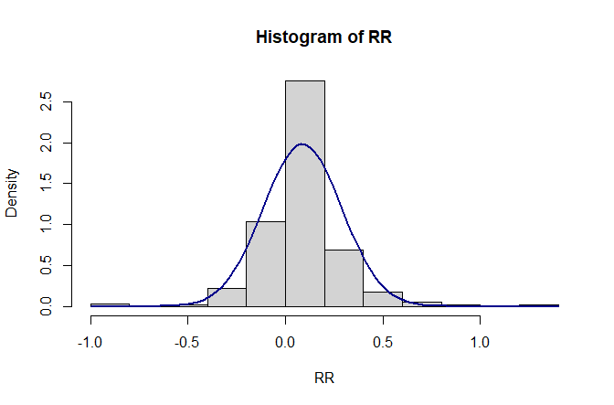

```r
RR<-ERA.Pits.Prep[Out.SubInd=="Soil Moisture"   & SubPrName=="MinTill-Planting Basins",yi]
hist(RR, prob=T)
curve(dnorm(x, mean=mean(RR), sd=sqrt(var(RR))), col="darkblue", lwd=2, add=TRUE, yaxt="n")
```

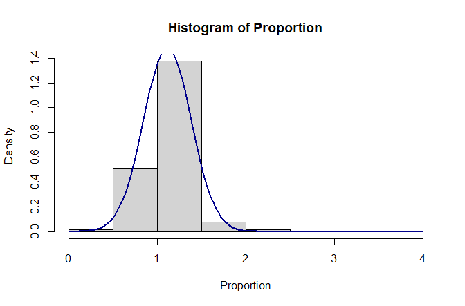

```r
Proportion<-ERA.Pits.Prep[Out.SubInd=="Soil Moisture"   & SubPrName=="MinTill-Planting Basins",MeanT/MeanC]
hist(Proportion, prob=T)
curve(dnorm(x, mean=mean(Proportion), sd=sqrt(var(Proportion))), col="darkblue", lwd=2, add=TRUE, yaxt="n")
```

##### Example of issue with ordering of numerator and denominator

Interestingly results can change if the numerator and denominator are swapped. For example:

```r
Con<-c(1000,1500,2000) # Control outcomes
Exp<-c(1100,500,1200) # Experimental outcomes

# ***Experimental outcome is numerator***
Exp/Con
```

```
#> [1] 1.1000000 0.3333333 0.6000000
```

```r
mean(Exp/Con)
```

```
#> [1] 0.6777778
```

```r
# % change estimated from mean of ratios
100*(mean(Exp/Con)-1)
```

```
#> [1] -32.22222
```

```r
# % change estimated from mean of response ratios
100*(exp(mean(log(Exp/Con)))-1)
```

```
#> [1] -39.63189
```

```r
# ***Control outcome is numerator***
Con/Exp
```

```
#> [1] 0.9090909 3.0000000 1.6666667
```

```r
mean(Con/Exp)
```

```
#> [1] 1.858586
```

```r
# % change estimated from mean of ratios
100*(mean(Con/Exp)-1)
```

```
#> [1] 85.85859
```

```r
# % change estimated from mean of response ratios
100*(exp(mean(log(Con/Exp)))-1)
```

```
#> [1] 65.65038
```

When averaging ratios if the experimental treatment is the numerator then the experimental treatment yields -32.2% less than the control, and if the control treatment is the numerator then we find the control yields 85.9% more than the experimental treatment. The results using response ratios are less dispersed (-39.6% vs 65.7%).

Which is true: 1) the control is 65.7% better than the experimental treatment or 2) the experimental treatment is 39.6% worse than the control?